# MSc SIA 26

# Data Splits

```python
#7 SPLIT DATA

from sklearn.model_selection import train_test_split

X = data.drop('Class', axis=1)
y = data['Class']

X_train, X_test, y_train, y_test = train_test_split(
    X, y, test_size=0.2, stratify=y, random_state=42
)

print(X_train.shape, X_test.shape)
```

```
(227845, 30) (56962, 30)
```

# The dataset is divided into training and testing subsets using stratified sampling to preserve the original class distribution. This is particularly important in imbalanced datasets to ensure that both subsets contain representative proportions of fraud cases. The split enables unbiased evaluation of the model’s performance on unseen data while maintaining consistency in class representation.

# Model- logistics Regression

```python
# MODEL---
# LOGISTIC REGRESSION

from sklearn.linear_model import LogisticRegression

model = LogisticRegression(class_weight='balanced', max_iter=1000)
model.fit(X_train, y_train)
```

```
LogisticRegression(class_weight='balanced', max_iter=1000)
```

# A logistic regression model is selected as the primary classification approach due to its interpretability, simplicity, and effectiveness for structured data. The model is configured with class weighting to address imbalance in the target variable. This choice allows for a focused and rigorous implementation while maintaining transparency in how predictions are generated.

# Prediction

```python
#9 PREDICTIONNNNNNNN

y_pred = model.predict(X_test)
y_prob = model.predict_proba(X_test)[:, 1]
```

The logistic regression model is trained using the prepared training dataset. Class weighting is applied to ensure that fraudulent transactions receive higher importance during learning. This step enables the model to learn patterns associated with fraud while mitigating the bias toward the majority class, resulting in a more balanced and meaningful predictive performance.

# Model Evaluation

```python
#10.1 CLASSIFICATION REPORT
from sklearn.metrics import classification_report

print(classification_report(y_test, y_pred))
```

```
              precision    recall  f1-score   support

           0       1.00      0.98      0.99     56864
           1       0.06      0.92      0.11        98

    accuracy                           0.98     56962
   macro avg       0.53      0.95      0.55     56962
weighted avg       1.00      0.98      0.99     56962
```

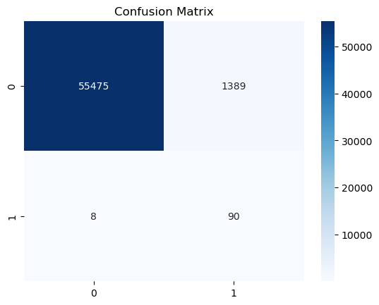

```python
#10.2 COFUSION MATRIX

from sklearn.metrics import confusion_matrix

cm = confusion_matrix(y_test, y_pred)

sns.heatmap(cm, annot=True, fmt='d', cmap='Blues')
plt.title("Confusion Matrix")
plt.show()
```

```python
#10.3 ROC AUC
from sklearn.metrics import roc_auc_score

print("ROC AUC:", roc_auc_score(y_test, y_prob))
```

```
ROC AUC: 0.9720323571887957
```

The trained model is used to generate predictions on the test dataset. Both class labels and probability scores are computed, allowing for flexible evaluation and threshold adjustment. Probability outputs are particularly important in fraud detection, as they enable ranking of transactions based on risk rather than relying solely on binary classification.Model performance is evaluated using metrics appropriate for imbalanced classification, including precision, recall, F1-score, and ROC-AUC. The confusion matrix provides a detailed breakdown of prediction outcomes. Emphasis is placed on recall, as correctly identifying fraudulent transactions is more critical than overall accuracy in this context.

# INTERPRETATION

# The dataset is highly imbalanced, with fraudulent transactions representing a very small share of total observations. After scaling the non-standardized variables and performing exploratory analysis, a logistic regression model with balanced class weights was trained. The results show that recall is more important than raw accuracy in this problem because missing fraudulent transactions is more costly than flagging some genuine transactions.

# LIMITATION

# This implementation has several limitations. First, the dataset is highly imbalanced, which makes prediction difficult. Second, logistic regression captures mainly linear relationships and may miss more complex fraud patterns. Third, the anonymized variables reduce interpretability. A natural next step would be to test boosting methods or threshold optimization.

# Future Improvement

Future work can extend this analysis by incorporating more advanced models such as gradient boosting or anomaly detection techniques. Additional improvements may include threshold optimization, cost-sensitive learning, and time-aware validation strategies. These approaches can enhance fraud detection performance and better reflect real-world deployment scenarios.